# Embodied Food GHG emissions According to Dietary Pattern

Colin Fay

2020-12-13

> Note: we already have another article about [GHG emissions and Diet](https://dataviz.vg/post/greenhouse-by-diet-2000kcal/). This new post relies on another source.

### 🔎 About the source

Climate change mitigation and health effects of varied dietary patterns in real-life settings throughout North America,

academic.oup.com/ajcn/article/100/suppl_1/490S/4576703

> With the nonvegetarian diet as reference, the mean percentage change in total GHGEs and change in annual emissions were −29.2% and −325 kg CO2e for the vegetarian and −21.6% and −241 kg CO2e for semivegetarian diets, respectively.

> Data from the Adventist Health Study 2 (AHS-2) were used to characterize and quantify the dietary patterns assessed. The AHS-2 is a large prospective cohort study of Seventh-day Adventists spread throughout the United States and Canada. Dietary intake was assessed by a self-administered food-frequency questionnaire of 210 food items including fruit, vegetables, legumes, grains, oils, dairy, fish, eggs, meat, beverages, and commercially prepared products such as dietary supplements, dry cereals, and vegetarian protein products. Dietary patterns were determined according to the reported combined intake of all meats, including fish. Vegetarians rarely or never consumed meats (<1 time/mo), semivegetarians consumed meats >1 time/mo but <1 time/wk, and nonvegetarians consumed meats at least 1 time/wk.

### 📈 Visualising the data

Visualization of *Embodied food greenhouse gas emissions, adjusted to 2000 kcal, according to dietary pattern*.

Three dietary patterns are studied (either Nonvegetarian, Semivegetarian, or Vegetarian).

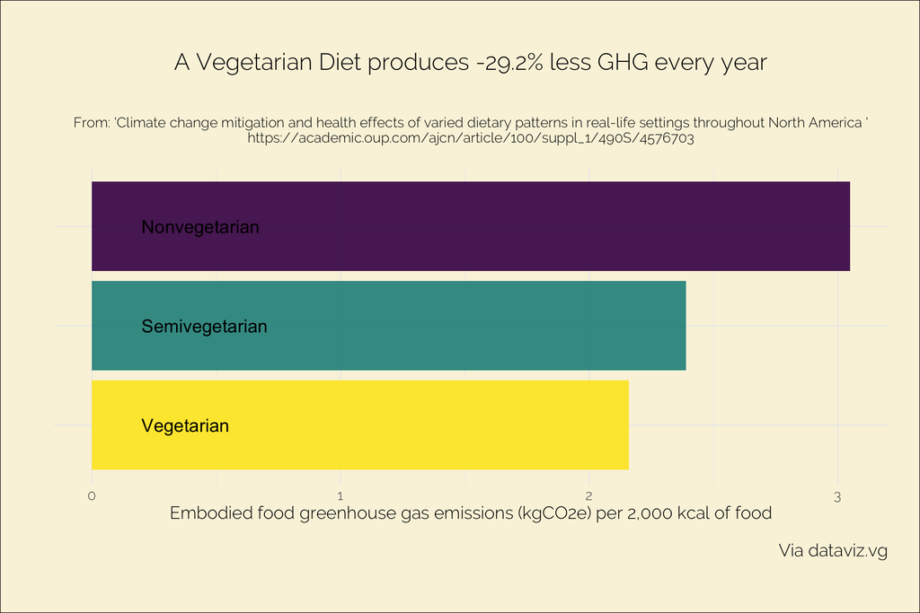

**Show the data**

| Dietary pattern | Mean GHG Emission |
| --- | --- |
| Nonvegetarian | 3.05 |
| Semivegetarian | 2.39 |
| Vegetarian | 2.16 |

Code behind this post is available [here](https://github.com/datavizvg/website/blob/main/content/post/2020-12-13-co2-diet.Rmd).